# Tugas Pertemuan 5

Author

Sabitala Dinika G1401231089

Published

September 21, 2025

# Import Library

```r
library(ggplot2)
library(tsibble)
library(tseries)
library(forecast)
library(TSA)
library(MASS)
library(readxl)
```

# Import Data

```r
jkt <- read_xlsx("~/punya dinoy/kuliah/Semester 5/MPDW/dataudarajkt.xlsx")
head(jkt)
```

```
# A tibble: 6 × 2
  periode  pm10
    <dbl> <dbl>
1       1    42
2       2    52
3       3    56
4       4    38
5       5    38
6       6    26
```

Data yang digunakan adalah data kualitas udara di Jakarta dengan variabel Y adalah pm10 (partikel berdiameter 10 mikron atau kurang).

# Split Data

Data akan di-split menjadi 80% data train dan 20% data test.

```r
# Hitung index batas 80%
n <- nrow(jkt)
n_train <- floor(0.8 * n)

# Split data
train_jkt <- jkt[1:n_train, ]
test_data  <- jkt[(n_train + 1):n, ]
```

```r
jkt.ts <- ts(train_jkt$pm10, start = 1, frequency = 1)
```

# Plot Time Series

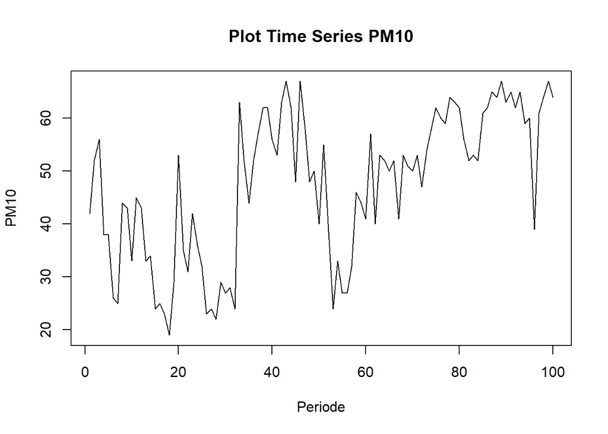

```r
plot(jkt.ts,
     type = "l",
     xlab = "Periode",
     ylab = "PM10",
     main = "Plot Time Series PM10")
```

Berdasarkan plot time series tersebut, terlihat bahwa data tidak stasioner dalam rataan, ditandai dengan adanya kecenderungan (tren) positif, dan juga tidak stasioner dalam ragam, ditandai dengan adanya lebar pita pada plot yang cenderung berbeda-beda.

# Cek Kestasioneran Data

## Kestasioneran dalam Rataan

### Plot ACF

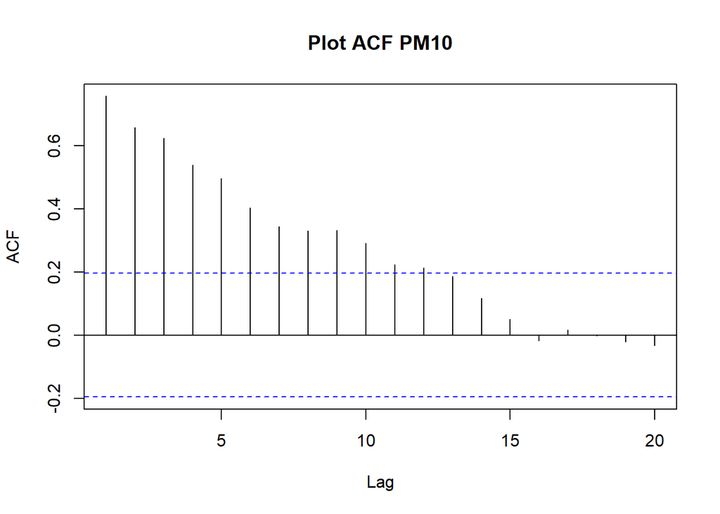

```r
acf(jkt.ts, main="Plot ACF PM10")
```

Plot ACF PM10 menunjukkan korelasi yang menurun secara perlahan pada banyak lag, sehingga menjadi indikasi kuat bahwa deret tidak stasioner dalam rataan.

### Uji ADF

```r
tseries::adf.test(jkt.ts)
```

```
    Augmented Dickey-Fuller Test

data:  jkt.ts
Dickey-Fuller = -3.1285, Lag order = 4, p-value = 0.1092
alternative hypothesis: stationary
```

Berdasarkan uji ADF tersebut, didapat p-value = 0.1092 lebih besar dari taraf nyata 5% sehingga gagal tolak $H_0$ yang menyatakan bahwa data tidak stasioner dalam rataan. Hal ini sesuai dengan hasil eksplorasi menggunakan plot time series dan plot ACF.

## Kestasioneran dalam Ragam

### Plot Box-Cox

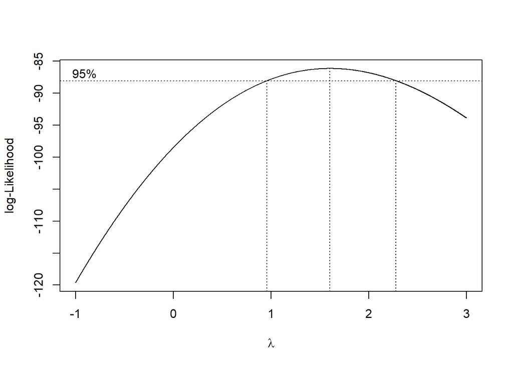

```r
bc <- boxcox(jkt.ts ~ train_jkt$periode, lambda = seq(-1, 3, 0.001))
```

```r
lambda <- bc$x[which.max(bc$y)]
lambda
```

```
[1] 1.603
```

```r
# Selang kepercayaan 95% untuk lambda
ci_lambda <- bc$x[bc$y > max(bc$y) - 0.5 * qchisq(0.95, 1)]

# Batas bawah dan batas atas
ci_lower <- min(ci_lambda)
ci_upper <- max(ci_lambda)

c(Batas_Bawah = ci_lower, Batas_Atas = ci_upper)
```

```
Batas_Bawah  Batas_Atas
      0.957       2.279
```

Hasil uji Box-Cox menunjukkan bahwa nilai lambda optimal berada pada 1.603 dengan selang kepercayaan 95% antara 0.957 hingga 2.279. Karena nilai λ = 1 termasuk dalam selang kepercayaannya, maka ragam data PM10 stasioner. Artinya, data dikatakan homoskedastisitas. Namun, batas bawah sangat mendekati nilai 1 dan untuk mencegah perubahan kestasioneran setelah melakukan differencing, maka penanganan ketidakstasioneran dalam ragam tetap dilakukan, yaitu dengan transformasi Box-Cox.

# Penanganan Ketidakstasioneran Data

## Transformasi Box-Cox

```r
jkt_transformasi <- BoxCox(jkt.ts, lambda = "auto")

lambda_terpilih <- attr(jkt_transformasi, "lambda")
print(paste("Lambda optimal:", lambda_terpilih))
```

```
[1] "Lambda optimal: 1.38154970552884"
```

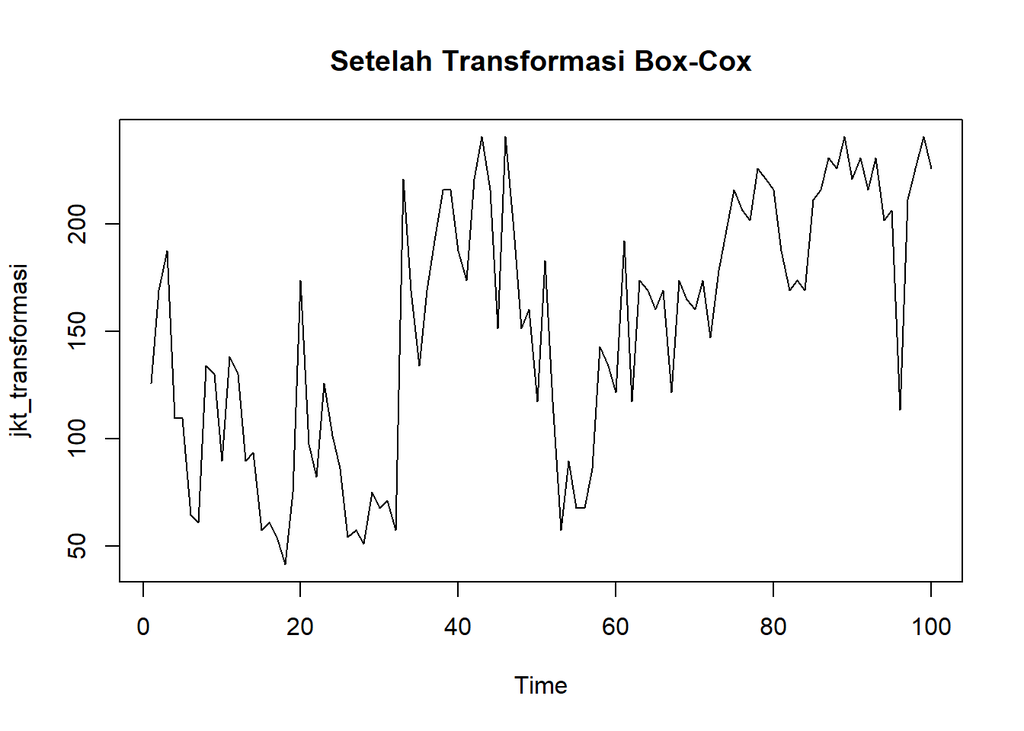

```r
plot(jkt_transformasi, type="l", main="Setelah Transformasi Box-Cox")
```

## Differencing Ordo 1

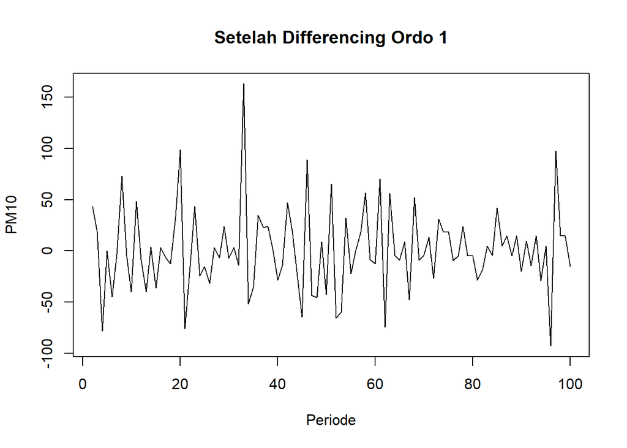

```r
jkt_diff1 <- diff(jkt_transformasi, differences = 1)
plot(jkt_diff1,
     type = "l",
     xlab = "Periode",
     ylab = "PM10",
     main = "Setelah Differencing Ordo 1")
```

Setelah dilakukan first differencing pada data PM10, pola fluktuasinya terlihat sudah berpusat di sekitar nol sepanjang deret waktu. Tren naik atau turun yang sebelumnya muncul pada data asli sudah tidak tampak lagi, sehingga rata-rata dapat dianggap stabil dari waktu ke waktu. Namun, ragam pada plot tersebut masih terlihat tidak menyebar dengan cukup konstan, maka dilakukan differencing ordo 2.

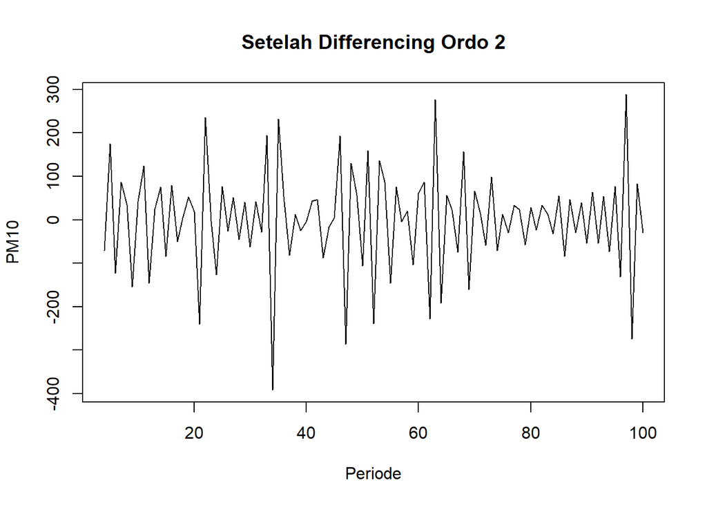

```r
jkt_diff2 <- diff(jkt_diff1, differences = 2)
plot(jkt_diff2,
     type = "l",
     xlab = "Periode",
     ylab = "PM10",
     main = "Setelah Differencing Ordo 2")
```